# Introduction:

**Is data set balanced?**

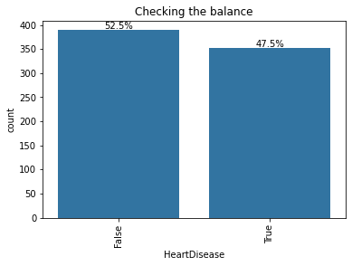

**Ratio of HeartDisease is approximately balanced in data set**

**Is gender feature is balanced in our data set?**

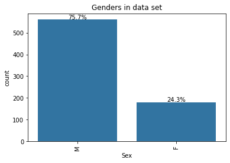

**What is the most effective features in HeartDisease ocurring?**

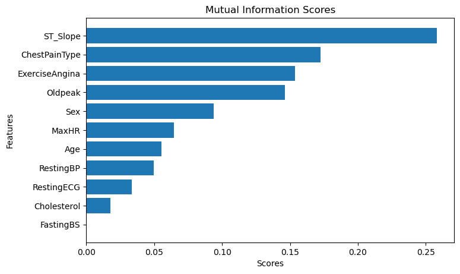

**ST_slope,CheastPainType are the most effictive features**

**How does Age affect max heart rate?**

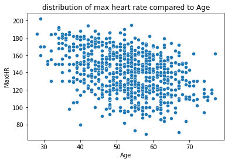

**Liklihood of Max heart rate being big while age increasing decreases.**

**What is the distribution of HeartDisease of that?**

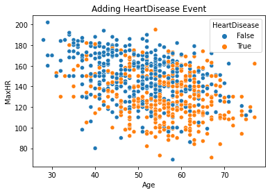

**Heart disease more likley in old age despite Max heart rate**

**Which gender is morelikely get heartdisease?**

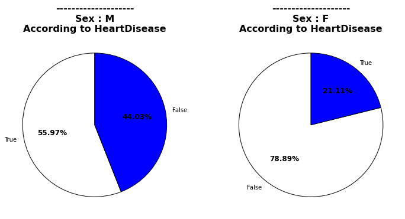

**Men is more likely to get Heart Disease**

# Conclusions:

**limitation We could have built a stronger model if we got more enough data**

1-S_T slope highly correlated with heart disease

2-data has been gathered from males more than females however heart disease more likely to occure in men than females

3-ExerciseAngina more likely to keep heart diseas away if it's false

4-if ST_slope tends to be Flat or down individual more likely to get a heart disease